# Practicum III

### Authors:

- Simin Zhang
- Yiman Liu
- Zhi Wen

## Part 1 (40 pts) Load XML

1. (5 pts) Create a normalized relational schema that contains minimally the following entities: Article, Journal, Author, History. Use the XML document to determine the appropriate attributes (fields/columns) for the entities (tables). While there may be other types of publications in the XML, you only need to deal with articles in journals. Create appropriate primary and foreign keys. Where necessary, add surrogate keys. Include an image of an ERD showing your model in your R Notebook.

#### Schema

Article(pmid, pub_model, title, pagination, abstract_copyright_info, author_list_complete, language, article_date)  
Journal(issn, issn_type, title, iso_abbreviation)  
Author(author_id, valid, last_name, fore_name, initials, affiliation)  
History(history_id, *article_id*, pub_status, pub_date)  
AbstractText(abstract_id, *article_id*, label, nlm_category, abstract_text)  
ArticleJournal(*article_id*, *journal_issn*, volume, issue, pub_date, cited_medium)  
ArticleAuthor(*article_id*, *author_id*)

#### ERD

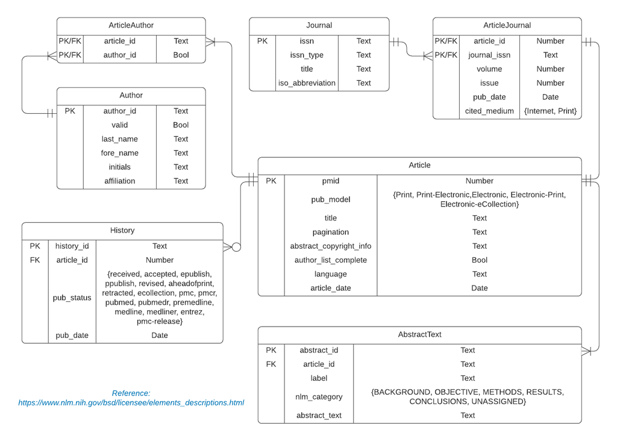

2. (5 pts) Realize the relational schema in SQLite (place the CREATE TABLE statements into SQL chunks in your R Notebook).

```r
library(DBI)
con <- dbConnect(RSQLite::SQLite(), "pubmed_normalized.sqlite")
```

```sql
CREATE TABLE If NOT EXISTS Article (
  pmid                      NUMERIC NOT NULL PRIMARY KEY,
  pub_model                 TEXT    CHECK(pub_model IN ('Print', 'Print-Electronic', 'Electronic', 'Electronic-Print', 'Electronic-eCollection')),
  title                     TEXT    NOT NULL,
  pagination                TEXT,
  abstract_copyright_info   TEXT,
  author_list_complete      BOOLEAN NOT NULL,
  language                  TEXT    NOT NULL,
  article_date              DATE
);
```

```sql
CREATE TABLE If NOT EXISTS Journal (
  issn              TEXT NOT NULL PRIMARY KEY,
  issn_type         TEXT NOT NULL,
  title             TEXT NOT NULL,
  iso_abbreviation  TEXT NOT NULL
);
```

```sql
CREATE TABLE If NOT EXISTS Author (
  author_id     TEXT    NOT NULL PRIMARY KEY,
  valid         BOOLEAN NOT NULL,
  last_name     TEXT    NOT NULL,
  fore_name     TEXT    NOT NULL,
  initials      TEXT,
  affiliation   TEXT
);
```

```sql
CREATE TABLE If NOT EXISTS History (
  history_id    TEXT    NOT NULL PRIMARY KEY,
  article_id    NUMERIC NOT NULL,
  pub_status    TEXT    CHECK(pub_status IN ('received', 'accepted', 'epublish', 'ppublish', 'revised', 'aheadofprint',
  'retracted', 'ecollection', 'pmc', 'pmcr', 'pubmed', 'pubmedr', 'premedline', 'medline', 'medliner', 'entrez', 'pmc-release')),
  pub_date      DATE    NOT NULL,
  FOREIGN KEY(article_id) REFERENCES Article(pmid)
);
```

```sql
CREATE TABLE If NOT EXISTS AbstractText (
  abstract_id    TEXT     NOT NULL PRIMARY KEY,
  article_id      NUMERIC NOT NULL,
  label           TEXT,
  nlm_category    TEXT    CHECK(nlm_category IN ('BACKGROUND', 'OBJECTIVE', 'METHODS', 'RESULTS', 'CONCLUSIONS', 'UNASSIGNED')),
  abstract_text   TEXT    NOT NULL,
  FOREIGN KEY(article_id) REFERENCES Article(pmid)
);
```

```sql
CREATE TABLE If NOT EXISTS ArticleJournal (
  article_id        NUMERIC NOT NULL,
  journal_issn      TEXT    NOT NULL,
  volume            TEXT    NOT NULL,
  issue             TEXT    NOT NULL,
  pub_date          DATE    NOT NULL,
  cited_medium      TEXT    CHECK(cited_medium IN ('Internet', 'Print')),
  PRIMARY KEY (article_id, journal_issn),
  FOREIGN KEY(article_id)   REFERENCES Article(pmid),
  FOREIGN KEY(journal_issn) REFERENCES Journal(issn)
);
```

```sql
CREATE TABLE If NOT EXISTS ArticleAuthor (
  article_id    NUMERIC NOT NULL,
  author_id     TEXT    NOT NULL,
  PRIMARY KEY (article_id, author_id),
  FOREIGN KEY(article_id) REFERENCES Article(pmid),
  FOREIGN KEY(author_id)  REFERENCES Author(author_id)
);
```

```sql
PRAGMA foreign_keys = 1
```

```r
print(dbListTables(con))
```

```
[1] "AbstractText"   "Article"        "ArticleAuthor"  "ArticleJournal" "Author"
[6] "History"        "Journal"
```

3. (30 pts) Extract and transform the data from the XML and then load into the appropriate tables in the database. You cannot use xmlToDataFrame but instead must parse the XML node by node using a combination of node-by-node tree traversal and XPath. It is not feasible to use XPath to extract all journals, then all authors, etc. as some are missing and won’t match up. You will need to iterate through the top-level nodes.

```r
library(XML)
```

```r
parseDateNode <- function(node){
  res <- NA
  for (i in 1:xmlSize(node))
  {
    if (i == 1)
    {
      res <- xmlValue(node[[i]])
    }
    else if (i > 1 && i < 4) {
      res <- paste0(res, '-', xmlValue(node[[i]]))
    }
    else if (i == 4) {
      res <- paste0(res, ' ', xmlValue(node[[i]]))
    }
    else {
      res <- paste0(res, ':', xmlValue(node[[i]]))
    }
  }
  return(res)
}
```

```r
xml <- xmlParse('pubmed_sample.xml')
root <- xmlRoot(xml)

art_pmids <- c()
art_pub_models <- c()
art_titles <- c()
art_paginations <- c()
art_languages <- c()
art_dates <- c()
art_copyrights <- c()
art_author_list_complete <- c()

art_issns <- c()
art_volumes <- c()
art_issues <- c()
art_pub_dates <- c()
art_cited_medium <- c()

abs_ids <- c()
abs_articles <- c()
abs_labels <- c()
abs_nlm_categories <- c()
abs_texts <- c()

hst_ids <- c()
hst_articles <- c()
hst_pub_status <- c()
hst_pub_dates <- c()

jnl_issn <- c()
jnl_issn_type <- c()
jnl_titles <- c()
jnl_iso_abbr <- c()

au_ids <- c()
au_valids <- c()
au_last_names <- c()
au_fore_names <- c()
au_initials <- c()
au_affilications <- c()
au_fullname_to_id <- c()

au_art_auids <- c()
au_art_artids <- c()

for (idx in 1:xmlSize(root))
{
  art_dates[idx] <- NA
  art_copyrights[idx] <- NA
  for (i in 1:xmlSize(root[[idx]]))
  {
    node <- root[[idx]][[i]]
    if (xmlName(node) == 'MedlineCitation')
    {
      for (j in 1:xmlSize(node))
      {
        if (xmlName(node[[j]]) == 'PMID')
        {
          art_pmids[idx] <- as.integer(xmlValue(node[[j]]))
        }
        else if (xmlName(node[[j]]) == 'Article') {
          article <- node[[j]]
          art_pub_models[idx] <- xmlAttrs(article)[1]
          for (k in 1:xmlSize(article))
          {
            if (xmlName(article[[k]]) == 'Journal')
            {
              journal <- article[[k]]
              issn <- xmlValue(journal[[1]])
              art_issns[idx] <- issn
              art_cited_medium[idx] <- xmlAttrs(journal[[2]])[1]
              art_volumes[idx] <- xmlValue(journal[[2]][[1]])
              art_issues[idx] <- xmlValue(journal[[2]][[2]])
              art_pub_dates[idx] <- parseDateNode(journal[[2]][[3]])
              if (!is.element(issn, jnl_issn))
              {
                id <- length(jnl_issn) + 1
                jnl_issn[id] <- issn
                jnl_issn_type[id] <- xmlAttrs(journal[[1]])[1]
                jnl_titles[id] <- xmlValue(journal[[3]])
                jnl_iso_abbr[id] <-xmlValue(journal[[4]])
              }
            }
            else if (xmlName(article[[k]]) == 'ArticleTitle') {
              art_titles[idx] <- xmlValue(article[[k]])
            }
            else if (xmlName(article[[k]]) == 'Pagination') {
              art_paginations[idx] <- xmlValue(article[[k]][[1]])
            }
            else if (xmlName(article[[k]]) == 'Language') {
              art_languages[idx] <- xmlValue(article[[k]])
            }
            else if (xmlName(article[[k]]) == 'ArticleDate') {
              art_dates[idx] <- parseDateNode(article[[k]])
            }
            else if (xmlName(article[[k]]) == 'AuthorList') {
              authorlist <- article[[k]]
              if (xmlAttrs(authorlist)[1] == 'Y')
              {
                art_author_list_complete[idx] <- TRUE
              }
              else {
                art_author_list_complete[idx] <- FALSE
              }
              for (m in 1:xmlSize(authorlist))
              {
                author <- authorlist[[m]]
                last_name <- NA
                fore_name <- NA
                initials <- NA
                affilication <- NA
                for (n in 1:xmlSize(author))
                {
                  if (xmlName(author[[n]]) == 'LastName')
                  {
                    last_name <- xmlValue(author[[n]])
                  }
                  else if (xmlName(author[[n]]) == 'ForeName') {
                    fore_name <- xmlValue(author[[n]])
                  }
                  else if (xmlName(author[[n]]) == 'Initials') {
                    initials <- xmlValue(author[[n]])
                  }
                  else if (xmlName(author[[n]]) == 'Affiliation') {
                    affilication <- xmlValue(author[[n]])
                  }
                }
                fullname <- paste0(last_name, '#', fore_name)
                auid <- NA
                if (fullname %in% names(au_fullname_to_id))
                {
                  auid <- au_fullname_to_id[fullname]
                }
                else {
                  id <- length(au_ids) + 1
                  auid <- paste0('au_', id)
                  au_fullname_to_id[fullname] <- auid
                  au_ids[id] <- auid
                  if (xmlAttrs(author)[1] =='Y')
                  {
                    au_valids[id] <- TRUE
                  }
                  else {
                    au_valids[id] <- FALSE
                  }
                  au_last_names[id] <- last_name
                  au_fore_names[id] <- fore_name
                  au_initials[id] <- initials
                  au_affilications[id] <- affilication


                }
                id <- length(au_art_artids) + 1
                au_art_auids[id] <- auid
                au_art_artids[id] <- art_pmids[idx]
              }
            }
            else if (xmlName(article[[k]]) == 'Abstract') {
              abstract <- article[[k]]
              abstract_texts <- c()
              for (m in 1:xmlSize(abstract))
              {
                if (xmlName(abstract[[m]]) == 'AbstractText')
                {
                  id <- length(abs_ids) + 1
                  abs_ids[id] <- paste0('abs_', id)
                  abs_articles[id] <- art_pmids[idx]
                  abs_texts[id] <- c(abstract_texts, xmlValue(abstract[[m]]))
                  attrs <- xmlAttrs(abstract[[m]])
                  if (length(attrs) > 0)
                  {
                    abs_labels[id] <- attrs[1]
                    abs_nlm_categories[id] <- attrs[2]
                  }
                  else {
                    abs_labels[id] <- NA
                    abs_nlm_categories[id] <- NA
                  }
                }
                else if (xmlName(abstract[[m]]) == 'CopyrightInformation') {
                  art_copyrights[idx] <- xmlValue(abstract[[m]])
                }
              }
            }
          }
        }
      }
    }
    else if (xmlName(node) == 'PubmedData') {
      for (j in 1:xmlSize(node))
      {
        if (xmlName(node[[j]]) == 'History')
        {
          history <- node[[j]]
          for (k in 1:xmlSize(history))
          {
            id <- length(hst_ids) + 1
            hst_ids[id] <- paste0('hst_', id)
            hst_articles[id] <- art_pmids[idx]
            hst_pub_status[id] <- xmlAttrs(history[[k]])[1]
            hst_pub_dates[id] <- parseDateNode(history[[k]])
          }
        }
      }
    }
  }
}
```

```r
df_article <- data.frame(
  pmid = art_pmids,
  pub_model = art_pub_models,
  title = art_titles,
  pagination = art_paginations,
  abstract_copyright_info = art_copyrights,
  author_list_complete = art_author_list_complete,
  language = art_languages,
  article_date = art_dates
)
df_abstract <- data.frame(
  abstract_id = abs_ids,
  article_id = abs_articles,
  label = abs_labels,
  nlm_category = abs_nlm_categories,
  abstract_text = abs_texts
)
df_history <- data.frame(
  history_id = hst_ids,
  article_id = hst_articles,
  pub_status = hst_pub_status,
  pub_date = hst_pub_dates
)
df_journal <- data.frame(
  issn = jnl_issn,
  issn_type = jnl_issn_type,
  title = jnl_titles,
  iso_abbreviation = jnl_iso_abbr
)
df_article_journal <- data.frame(
  article_id = art_pmids,
  journal_issn = art_issns,
  volume = art_volumes,
  issue = art_issues,
  pub_date = art_pub_dates,
  cited_medium = art_cited_medium
)
df_author <- data.frame(
  author_id = au_ids,
  valid = au_valids,
  last_name = au_last_names,
  fore_name = au_fore_names,
  initials = au_initials,
  affiliation = au_affilications
)
df_article_author <- data.frame(
  article_id = au_art_artids,
  author_id = au_art_auids
)
```

```r
print(df_article)
```

| pmid | pub_model | title | pagination | abstract_copyright_info | author_list_complete | language | article_date |
| --- | --- | --- | --- | --- | --- | --- | --- |
| 23874253 | Print-Electronic | Regional anesthesia for children undergoing orthopedic ambulatory surgeries in the United States, 1996-2006. | 133-6 | NA | TRUE | eng | 2012-06-20 |
| 23194934 | Print-Electronic | Demographics and perioperative outcome in patients with depression and anxiety undergoing total joint arthroplasty: a population-based study. | 149-57 | Copyright © 2013 The Academy of Psychosomatic Medicine. Published by Elsevier Inc. All rights reserved. | TRUE | eng | 2012-11-27 |
| 23091119 | Print | Cerebrovascular reserve and stroke risk in patients with carotid stenosis or occlusion: a systematic review and meta-analysis. | 2884-91 | NA | TRUE | eng | NA |
| 23080348 | Print | Comparative perioperative outcomes associated with neuraxial versus general anesthesia for simultaneous bilateral total knee arthroplasty. | 638-44 | NA | TRUE | eng | NA |
| 23068970 | Print-Electronic | Vagus nerve stimulation vs. corpus callosotomy in the treatment of Lennox-Gastaut syndrome: a meta-analysis. | 3-8 | Copyright © 2012 British Epilepsy Association. Published by Elsevier Ltd. All rights reserved. | TRUE | eng | 2012-10-12 |
| 23008025 | Print-Electronic | Have bilateral total knee arthroplasties become safer? A population-based trend analysis. | 17-25 | NA | TRUE | eng | 2012-09-25 |
| 22677144 | Print-Electronic | The metabolic syndrome in patients undergoing knee and hip arthroplasty: trends and in-hospital outcomes in the United States. | 1743-1749.e1 | Copyright © 2012 Elsevier Inc. All rights reserved. | TRUE | eng | 2012-06-05 |
| 22634871 | Print | Utilization of critical care services among patients undergoing total hip and knee arthroplasty: epidemiology and risk factors. | 107-16 | NA | TRUE | eng | NA |
| 22434554 | Print-Electronic | Visualization of the normal appendix with MR enterography in children. | 959-64 | NA | TRUE | eng | 2012-03-21 |
| 22426260 | Print | FDG-PET assessment of rectal cancer response to neoadjuvant chemoradiotherapy is not associated with long-term prognosis: a prospective evaluation. | 378-86 | NA | TRUE | eng | NA |

[output cut: 9 more lines]

```r
print(df_journal)
```

| issn | issn_type | title | iso_abbreviation |
| --- | --- | --- | --- |
| 1556-3316 | Print | HSS journal : the musculoskeletal journal of Hospital for Special Surgery | HSS J |
| 1545-7206 | Electronic | Psychosomatics | Psychosomatics |
| 1524-4628 | Electronic | Stroke; a journal of cerebral circulation | Stroke |
| 1532-8651 | Electronic | Regional anesthesia and pain medicine | Reg Anesth Pain Med |
| 1532-2688 | Electronic | Seizure : the journal of the British Epilepsy Association | Seizure |
| 1528-1132 | Electronic | Clinical orthopaedics and related research | Clin. Orthop. Relat. Res. |
| 1532-8406 | Electronic | The Journal of arthroplasty | J Arthroplasty |
| 1528-1175 | Electronic | Anesthesiology | Anesthesiology |
| 1432-1998 | Electronic | Pediatric radiology | Pediatr Radiol |
| 1530-0358 | Electronic | Diseases of the colon and rectum | Dis. Colon Rectum |

[output cut: 6 more lines]

```r
print(df_author)
```

| author_id | valid | last_name | fore_name | initials | affiliation |
| --- | --- | --- | --- | --- | --- |
| au_1 | TRUE | Kuo | Cassie | C | Department of Anesthesiology, Hospital for Special Surgery, 535 East 70th Street, New York, NY 10021 USA. |
| au_2 | TRUE | Edwards | Alison | A | NA |
| au_3 | TRUE | Mazumdar | Madhu | M | NA |
| au_4 | TRUE | Memtsoudis | Stavros G | SG | NA |
| au_5 | TRUE | Stundner | Ottokar | O | Department of Anesthesiology, Hospital for Special Surgery, Weill Medical College of Cornell University, New York, NY, USA. |
| au_6 | TRUE | Kirksey | Meghan | M | NA |
| au_7 | TRUE | Chiu | Ya Lin | YL | NA |
| au_8 | TRUE | Poultsides | Lazaros | L | NA |
| au_9 | TRUE | Gerner | Peter | P | NA |
| au_10 | TRUE | Gupta | Ajay | A | Department of Radiology, Weill Cornell Medical School, New York-Presbyterian Hospital, 525 East 68th Street, Starr 8A, Box 141, New York, NY 10065, USA. ajg9004@med.cornell.edu |

[output cut: 74 more lines]

```r
print(df_history)
```

| history_id | article_id | pub_status | pub_date |
| --- | --- | --- | --- |
| hst_1 | 23874253 | received | 2012-1-15 |
| hst_2 | 23874253 | accepted | 2012-4-16 |
| hst_3 | 23874253 | epublish | 2012-6-20 |
| hst_4 | 23874253 | entrez | 2013-7-23 6:0 |
| hst_5 | 23874253 | pubmed | 2013-7-23 6:0 |
| hst_6 | 23874253 | medline | 2013-7-23 6:1 |
| hst_7 | 23194934 | received | 2012-7-16 |
| hst_8 | 23194934 | revised | 2012-8-17 |
| hst_9 | 23194934 | accepted | 2012-8-20 |
| hst_10 | 23194934 | aheadofprint | 2012-11-27 |

[output cut: 84 more lines]

```r
print(df_abstract)
```

| abstract_id | article_id | label | nlm_category | abstract_text |
| --- | --- | --- | --- | --- |
| abs_1 | 23874253 | BACKGROUND | BACKGROUND | Our objective was to evaluate national trends in regional anesthetic techniques among children undergoing ambulatory orthopedic procedures. |
| abs_2 | 23874253 | PURPOSE AND QUESTIONS | UNASSIGNED | We aimed to determine whether an increase in regional anesthetics was primarily driven by an increase in the number of peripheral nerve blocks performed rather than an increase in neuraxial techniques… |
| abs_3 | 23874253 | PATIENTS AND METHODS | METHODS | Our study sample included any pediatric patient (i.e., <18 years old) who underwent an orthopedic ambulatory procedure in 1996 and 2006. We obtained data on ambulatory surgical procedures by accessing… |
| abs_4 | 23874253 | RESULTS | RESULTS | The proportion of peripheral nerve blocks performed for ambulatory surgery more than doubled from 1996 (4.4 %) to 2006 (8.1 %). A significantly larger proportion of orthopedic procedures were being pe… |
| abs_5 | 23874253 | CONCLUSIONS | CONCLUSIONS | There was a significant increase in the use of peripheral nerve blocks for children undergoing ambulatory orthopedic procedures in the USA, while neuraxial techniques became less common over the 10-ye… |
| abs_6 | 23194934 | BACKGROUND | BACKGROUND | Depression and anxiety are highly prevalent psychiatric disorders. However, little is known about their impact on outcomes in the perioperative setting. This study is intended to gain insight into epi… |
| abs_7 | 23194934 | METHODS | METHODS | We obtained the National Inpatient Sample from the Hospital Cost and Utilization Project for each year between 2000 and 2008. Entries indicating the performance of primary total hip and knee arthropla… |
| abs_8 | 23194934 | RESULTS | RESULTS | We identified 1,212,493 patients undergoing arthroplasty between 2000 and 2008. The prevalence of depression and anxiety significantly increased over time. Patients with either condition had higher ho… |
| abs_9 | 23194934 | CONCLUSIONS | CONCLUSIONS | Patients suffering from depression, anxiety, or both require more healthcare resources in a perioperative setting. However, lower short-term mortality in spite of higher comorbidity burden and without… |
| abs_10 | 23091119 | BACKGROUND AND PURPOSE | OBJECTIVE | Impairments in cerebrovascular reserve (CVR) have been variably associated with increased risk of ischemic events and may stratify stroke risk in patients with high-grade internal carotid artery steno… |

[output cut: 71 more lines]

```r
print(df_article_journal)
```

| article_id | journal_issn | volume | issue | pub_date | cited_medium |
| --- | --- | --- | --- | --- | --- |
| 23874253 | 1556-3316 | 8 | 2 | 2012-Jul | Print |
| 23194934 | 1545-7206 | 54 | 2 | 2013 Mar-Apr | Internet |
| 23091119 | 1524-4628 | 43 | 11 | 2012-Nov | Internet |
| 23080348 | 1532-8651 | 37 | 6 | 2012 Nov-Dec | Internet |
| 23068970 | 1532-2688 | 22 | 1 | 2013-Jan | Internet |
| 23008025 | 1528-1132 | 471 | 1 | 2013-Jan | Internet |
| 22677144 | 1532-8406 | 27 | 10 | 2012-Dec | Internet |
| 22634871 | 1528-1175 | 117 | 1 | 2012-Jul | Internet |
| 22434554 | 1432-1998 | 42 | 8 | 2012-Aug | Internet |
| 22426260 | 1530-0358 | 55 | 4 | 2012-Apr | Internet |

[output cut: 9 more lines]

```r
print(df_article_author)
```

| article_id | author_id |
| --- | --- |
| 23874253 | au_1 |
| 23874253 | au_2 |
| 23874253 | au_3 |
| 23874253 | au_4 |
| 23194934 | au_5 |
| 23194934 | au_6 |
| 23194934 | au_7 |
| 23194934 | au_3 |
| 23194934 | au_8 |
| 23194934 | au_9 |

[output cut: 126 more lines]

```sql
SELECT * FROM Article
```

| pmid | pub_model | title | pagination | abstract_copyright_info | author_list_complete | language | article_date |
| --- | --- | --- | --- | --- | --- | --- | --- |
| 23874253 | Print-Electronic | Regional anesthesia for children undergoing orthopedic ambulatory surgeries in the United States, 1996-2006. | 133-6 | NA | 1 | eng | 2012-06-20 |
| 23194934 | Print-Electronic | Demographics and perioperative outcome in patients with depression and anxiety undergoing total joint arthroplasty: a population-based study. | 149-57 | Copyright © 2013 The Academy of Psychosomatic Medicine. Published by Elsevier Inc. All rights reserved. | 1 | eng | 2012-11-27 |
| 23091119 | Print | Cerebrovascular reserve and stroke risk in patients with carotid stenosis or occlusion: a systematic review and meta-analysis. | 2884-91 | NA | 1 | eng | NA |
| 23080348 | Print | Comparative perioperative outcomes associated with neuraxial versus general anesthesia for simultaneous bilateral total knee arthroplasty. | 638-44 | NA | 1 | eng | NA |
| 23068970 | Print-Electronic | Vagus nerve stimulation vs. corpus callosotomy in the treatment of Lennox-Gastaut syndrome: a meta-analysis. | 3-8 | Copyright © 2012 British Epilepsy Association. Published by Elsevier Ltd. All rights reserved. | 1 | eng | 2012-10-12 |
| 23008025 | Print-Electronic | Have bilateral total knee arthroplasties become safer? A population-based trend analysis. | 17-25 | NA | 1 | eng | 2012-09-25 |
| 22677144 | Print-Electronic | The metabolic syndrome in patients undergoing knee and hip arthroplasty: trends and in-hospital outcomes in the United States. | 1743-1749.e1 | Copyright © 2012 Elsevier Inc. All rights reserved. | 1 | eng | 2012-06-05 |
| 22634871 | Print | Utilization of critical care services among patients undergoing total hip and knee arthroplasty: epidemiology and risk factors. | 107-16 | NA | 1 | eng | NA |
| 22434554 | Print-Electronic | Visualization of the normal appendix with MR enterography in children. | 959-64 | NA | 1 | eng | 2012-03-21 |
| 22426260 | Print | FDG-PET assessment of rectal cancer response to neoadjuvant chemoradiotherapy is not associated with long-term prognosis: a prospective evaluation. | 378-86 | NA | 1 | eng | NA |

[output cut: 9 more lines]

```sql
SELECT * FROM Journal
```

| issn | issn_type | title | iso_abbreviation |
| --- | --- | --- | --- |
| 1556-3316 | Print | HSS journal : the musculoskeletal journal of Hospital for Special Surgery | HSS J |
| 1545-7206 | Electronic | Psychosomatics | Psychosomatics |
| 1524-4628 | Electronic | Stroke; a journal of cerebral circulation | Stroke |
| 1532-8651 | Electronic | Regional anesthesia and pain medicine | Reg Anesth Pain Med |
| 1532-2688 | Electronic | Seizure : the journal of the British Epilepsy Association | Seizure |
| 1528-1132 | Electronic | Clinical orthopaedics and related research | Clin. Orthop. Relat. Res. |
| 1532-8406 | Electronic | The Journal of arthroplasty | J Arthroplasty |
| 1528-1175 | Electronic | Anesthesiology | Anesthesiology |
| 1432-1998 | Electronic | Pediatric radiology | Pediatr Radiol |
| 1530-0358 | Electronic | Diseases of the colon and rectum | Dis. Colon Rectum |

[output cut: 6 more lines]

```sql
SELECT * FROM Author
```

| author_id | valid | last_name | fore_name | initials | affiliation |
| --- | --- | --- | --- | --- | --- |
| au_1 | 1 | Kuo | Cassie | C | Department of Anesthesiology, Hospital for Special Surgery, 535 East 70th Street, New York, NY 10021 USA. |
| au_2 | 1 | Edwards | Alison | A | NA |
| au_3 | 1 | Mazumdar | Madhu | M | NA |
| au_4 | 1 | Memtsoudis | Stavros G | SG | NA |
| au_5 | 1 | Stundner | Ottokar | O | Department of Anesthesiology, Hospital for Special Surgery, Weill Medical College of Cornell University, New York, NY, USA. |
| au_6 | 1 | Kirksey | Meghan | M | NA |
| au_7 | 1 | Chiu | Ya Lin | YL | NA |
| au_8 | 1 | Poultsides | Lazaros | L | NA |
| au_9 | 1 | Gerner | Peter | P | NA |
| au_10 | 1 | Gupta | Ajay | A | Department of Radiology, Weill Cornell Medical School, New York-Presbyterian Hospital, 525 East 68th Street, Starr 8A, Box 141, New York, NY 10065, USA. ajg9004@med.cornell.edu |

[output cut: 74 more lines]

```sql
SELECT * FROM History
```

| history_id | article_id | pub_status | pub_date |
| --- | --- | --- | --- |
| hst_1 | 23874253 | received | 2012-1-15 |
| hst_2 | 23874253 | accepted | 2012-4-16 |
| hst_3 | 23874253 | epublish | 2012-6-20 |
| hst_4 | 23874253 | entrez | 2013-7-23 6:0 |
| hst_5 | 23874253 | pubmed | 2013-7-23 6:0 |
| hst_6 | 23874253 | medline | 2013-7-23 6:1 |
| hst_7 | 23194934 | received | 2012-7-16 |
| hst_8 | 23194934 | revised | 2012-8-17 |
| hst_9 | 23194934 | accepted | 2012-8-20 |
| hst_10 | 23194934 | aheadofprint | 2012-11-27 |

[output cut: 84 more lines]

```sql
SELECT * FROM AbstractText
```

| abstract_id | article_id | label | nlm_category | abstract_text |
| --- | --- | --- | --- | --- |
| abs_1 | 23874253 | BACKGROUND | BACKGROUND | Our objective was to evaluate national trends in regional anesthetic techniques among children undergoing ambulatory orthopedic procedures. |
| abs_2 | 23874253 | PURPOSE AND QUESTIONS | UNASSIGNED | We aimed to determine whether an increase in regional anesthetics was primarily driven by an increase in the number of peripheral nerve blocks performed rather than an increase in neuraxial techniques… |
| abs_3 | 23874253 | PATIENTS AND METHODS | METHODS | Our study sample included any pediatric patient (i.e., <18 years old) who underwent an orthopedic ambulatory procedure in 1996 and 2006. We obtained data on ambulatory surgical procedures by accessing… |
| abs_4 | 23874253 | RESULTS | RESULTS | The proportion of peripheral nerve blocks performed for ambulatory surgery more than doubled from 1996 (4.4 %) to 2006 (8.1 %). A significantly larger proportion of orthopedic procedures were being pe… |
| abs_5 | 23874253 | CONCLUSIONS | CONCLUSIONS | There was a significant increase in the use of peripheral nerve blocks for children undergoing ambulatory orthopedic procedures in the USA, while neuraxial techniques became less common over the 10-ye… |
| abs_6 | 23194934 | BACKGROUND | BACKGROUND | Depression and anxiety are highly prevalent psychiatric disorders. However, little is known about their impact on outcomes in the perioperative setting. This study is intended to gain insight into epi… |
| abs_7 | 23194934 | METHODS | METHODS | We obtained the National Inpatient Sample from the Hospital Cost and Utilization Project for each year between 2000 and 2008. Entries indicating the performance of primary total hip and knee arthropla… |
| abs_8 | 23194934 | RESULTS | RESULTS | We identified 1,212,493 patients undergoing arthroplasty between 2000 and 2008. The prevalence of depression and anxiety significantly increased over time. Patients with either condition had higher ho… |
| abs_9 | 23194934 | CONCLUSIONS | CONCLUSIONS | Patients suffering from depression, anxiety, or both require more healthcare resources in a perioperative setting. However, lower short-term mortality in spite of higher comorbidity burden and without… |
| abs_10 | 23091119 | BACKGROUND AND PURPOSE | OBJECTIVE | Impairments in cerebrovascular reserve (CVR) have been variably associated with increased risk of ischemic events and may stratify stroke risk in patients with high-grade internal carotid artery steno… |

[output cut: 71 more lines]

```sql
SELECT * FROM ArticleJournal
```

| article_id | journal_issn | volume | issue | pub_date | cited_medium |
| --- | --- | --- | --- | --- | --- |
| 23874253 | 1556-3316 | 8 | 2 | 2012-Jul | Print |
| 23194934 | 1545-7206 | 54 | 2 | 2013 Mar-Apr | Internet |
| 23091119 | 1524-4628 | 43 | 11 | 2012-Nov | Internet |
| 23080348 | 1532-8651 | 37 | 6 | 2012 Nov-Dec | Internet |
| 23068970 | 1532-2688 | 22 | 1 | 2013-Jan | Internet |
| 23008025 | 1528-1132 | 471 | 1 | 2013-Jan | Internet |
| 22677144 | 1532-8406 | 27 | 10 | 2012-Dec | Internet |
| 22634871 | 1528-1175 | 117 | 1 | 2012-Jul | Internet |
| 22434554 | 1432-1998 | 42 | 8 | 2012-Aug | Internet |
| 22426260 | 1530-0358 | 55 | 4 | 2012-Apr | Internet |

[output cut: 9 more lines]

```sql
SELECT * FROM ArticleAuthor
```

| article_id | author_id |
| --- | --- |
| 23874253 | au_1 |
| 23874253 | au_2 |
| 23874253 | au_3 |
| 23874253 | au_4 |
| 23194934 | au_5 |
| 23194934 | au_6 |
| 23194934 | au_7 |
| 23194934 | au_3 |
| 23194934 | au_8 |
| 23194934 | au_9 |

[output cut: 126 more lines]

## Part 3 (20 pts) Explore and Mine Data

1. (10 pts) Write queries using your data warehouse to explore whether the publications show a seasonal pattern. Look beyond the pattern of number of publications per season. Adjust your fact tables as needed to support your new queries. If you need to update the fact table, document your changes and your reasons why the changes are needed.
2. (10 pts) Either (a) visualize (graph/plot) the data from the previous step using R to explore seasonality and explain what you found, or (b) build a predictive model to forecast the expected number of publications for a quarter. (Note that we do not cover predictive modeling in this course, so if you do not know this from a prior course, then simply create the visualization.)